# Group12-Project3

## 5. Perform a local sensitivity analysis for each of the parameters of your selected model and make a single plot with the sensitivity functions for each parameter.

```r
relativeSensitivity <- function(FUN, thetas, xdata = 0:45, eps = 1e-5) {
    yhat <- do.call(FUN, list(xdata, thetas))
    S <- matrix(NA, nrow = length(xdata), ncol = length(thetas))
    for (p in 1:length(thetas)) {
        thetas. <- thetas
        thetas.[p] <- thetas[p] * (1+eps)
        yhat. <- do.call(FUN, list(xdata, thetas.))
        S[, p] <- ((yhat. - yhat) / (eps*thetas[p])) * abs(thetas[p]) #Sensitivity with respect to parameters.
    }

    return(S)
}

xseq <- seq(min(our.times), max(our.times), length.out=200)

SensArray <- relativeSensitivity(double.monod, doublefit$par, xdata = xseq,
                                 eps = 1e-5)
```

To compare sensitivities of each parameter, relative sensitivity is used. Relative sensitivity with respect to parameter is $\frac{\partial y_i(t)}{\partial \theta_j} \cdot \theta_j$.

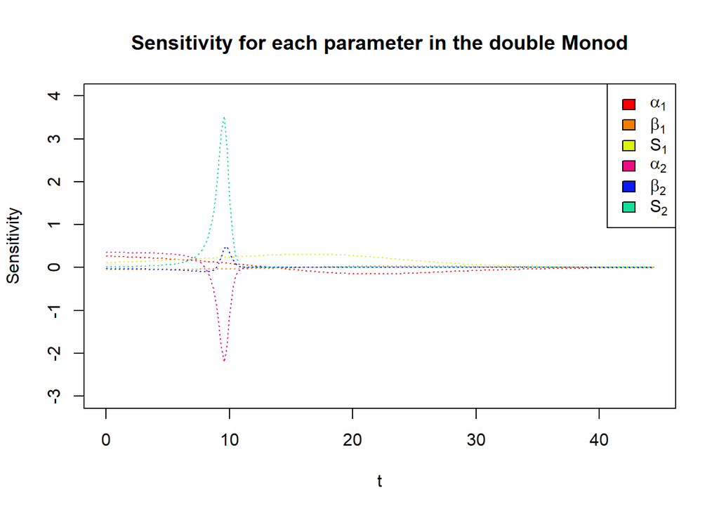

```r
plot(xseq, SensArray[,1],  main = "Sensitivity for each parameter in the double Monod", type = "l", lty=3, frame = TRUE, pch = 18,
     col = "red", ylim = c(-3,4), xlab = "t",
     ylab = "Sensitivity")
lines(xseq, SensArray[,2], pch = 18, col = "#F07F00", type = "l", lty = 3)
lines(xseq, SensArray[,3], pch = 18, col = "#D9F50C", type = "l", lty = 3)
lines(xseq, SensArray[,4], pch = 18, col = "#EB0C82", type = "l", lty = 3)
lines(xseq, SensArray[,5], pch = 18, col = "#0C1AF5", type = "l", lty = 3)
lines(xseq, SensArray[,6], pch = 18, col = "#16DE98", type = "l", lty = 3)
legend(x = "topright", legend = c(expression(alpha[1]), expression(beta[1]), expression(S[1]), expression(alpha[2]), expression(beta[2]), expression(S[2])), fill = c("red", "#F07F00", "#D9F50C", "#EB0C82", "#0C1AF5", "#16DE98"))
```

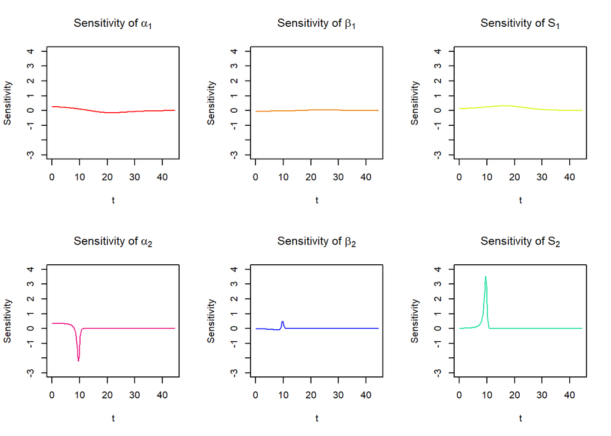

```r
par(mfrow=c(2, 3))
plot(xseq, SensArray[,1],  main = expression(paste("Sensitivity of ", alpha[1])), type = "l", frame = TRUE, pch = 18,
     col = "red", ylim = c(-3,4), xlab = "t",
     ylab = "Sensitivity")
plot(xseq, SensArray[,2],  main = expression(paste("Sensitivity of ", beta[1])), type = "l", frame = TRUE, pch = 18,
     col = "#F07F00", ylim = c(-3,4), xlab = "t",
     ylab = "Sensitivity")
plot(xseq, SensArray[,3],  main = expression(paste("Sensitivity of ", S[1])), type = "l", frame = TRUE, pch = 18,
     col = "#D9F50C", ylim = c(-3,4), xlab = "t",
     ylab = "Sensitivity")
plot(xseq, SensArray[,4],  main = expression(paste("Sensitivity of ", alpha[2])), type = "l", frame = TRUE, pch = 18,
     col = "#EB0C82", ylim = c(-3,4), xlab = "t",
     ylab = "Sensitivity")
plot(xseq, SensArray[,5],  main = expression(paste("Sensitivity of ", beta[2])), type = "l", frame = TRUE, pch = 18,
     col = "#0C1AF5", ylim = c(-3,4), xlab = "t",
     ylab = "Sensitivity")
plot(xseq, SensArray[,6],  main = expression(paste("Sensitivity of ", S[2])), type = "l", frame = TRUE, pch = 18,
     col = "#16DE98", ylim = c(-3,4), xlab = "t",
     ylab = "Sensitivity")
```

Sensitivity of all parameters eventually converges to 0 as time goes. Two parameters, $S_2$ and $\alpha_2$, are the most sensitive among parameters in the model and each pulses positively or negatively at rough time 10, respectively. The sensitivity of $\beta_2$ also pulses at the same time, but not much as former two.